# Clustering and Classification chapter

### Task4: Standardizing the dataset and print out summaries

```r
# here we are standardizing the data by scaling using the scale() function
boston_scaled <- scale(Boston)

# We shall print the summary of the scaled data by using the function symmary()
summary(boston_scaled)
```

```
##       crim                 zn               indus              chas
##  Min.   :-0.419367   Min.   :-0.48724   Min.   :-1.5563   Min.   :-0.2723
##  1st Qu.:-0.410563   1st Qu.:-0.48724   1st Qu.:-0.8668   1st Qu.:-0.2723
##  Median :-0.390280   Median :-0.48724   Median :-0.2109   Median :-0.2723
##  Mean   : 0.000000   Mean   : 0.00000   Mean   : 0.0000   Mean   : 0.0000
##  3rd Qu.: 0.007389   3rd Qu.: 0.04872   3rd Qu.: 1.0150   3rd Qu.:-0.2723
##  Max.   : 9.924110   Max.   : 3.80047   Max.   : 2.4202   Max.   : 3.6648
##       nox                rm               age               dis
##  Min.   :-1.4644   Min.   :-3.8764   Min.   :-2.3331   Min.   :-1.2658
##  1st Qu.:-0.9121   1st Qu.:-0.5681   1st Qu.:-0.8366   1st Qu.:-0.8049
##  Median :-0.1441   Median :-0.1084   Median : 0.3171   Median :-0.2790
##  Mean   : 0.0000   Mean   : 0.0000   Mean   : 0.0000   Mean   : 0.0000
##  3rd Qu.: 0.5981   3rd Qu.: 0.4823   3rd Qu.: 0.9059   3rd Qu.: 0.6617
##  Max.   : 2.7296   Max.   : 3.5515   Max.   : 1.1164   Max.   : 3.9566
##       rad               tax             ptratio            black
##  Min.   :-0.9819   Min.   :-1.3127   Min.   :-2.7047   Min.   :-3.9033
##  1st Qu.:-0.6373   1st Qu.:-0.7668   1st Qu.:-0.4876   1st Qu.: 0.2049
##  Median :-0.5225   Median :-0.4642   Median : 0.2746   Median : 0.3808
##  Mean   : 0.0000   Mean   : 0.0000   Mean   : 0.0000   Mean   : 0.0000
##  3rd Qu.: 1.6596   3rd Qu.: 1.5294   3rd Qu.: 0.8058   3rd Qu.: 0.4332
##  Max.   : 1.6596   Max.   : 1.7964   Max.   : 1.6372   Max.   : 0.4406
##      lstat              medv
##  Min.   :-1.5296   Min.   :-1.9063
##  1st Qu.:-0.7986   1st Qu.:-0.5989
##  Median :-0.1811   Median :-0.1449
##  Mean   : 0.0000   Mean   : 0.0000
##  3rd Qu.: 0.6024   3rd Qu.: 0.2683
##  Max.   : 3.5453   Max.   : 2.9865
```

The variables of the “scaled data” all have their mean to be zero (0)

```r
# Lets us check whether the scaled data is data frame or not by using is.data.frame() function
is.data.frame(boston_scaled)
```

```
## [1] FALSE
```

Note that the scaled data is not data frame. We will now convert the boston_scale to data frame by usinf the next step.

```r
# Making the boston_scaled data a data frame
boston_scaled <- as.data.frame(boston_scaled)
is.data.frame(boston_scaled)
```

```
## [1] TRUE
```

#### Task 4.2 Create a categorical variable of the crime rate in the Boston dataset

Now the boston_scaled is now a data frame. Hence, we can continue other analysis.

```r
#Let us examine the crime variable of the scaled data
summary(boston_scaled$crim)
```

```
##      Min.   1st Qu.    Median      Mean   3rd Qu.      Max.
## -0.419367 -0.410563 -0.390280  0.000000  0.007389  9.924110
```

```r
# create a quantile vector of crime
q_vector <- quantile(boston_scaled$crim)
# Let us print the quantile vector of crime rate
q_vector
```

```
##           0%          25%          50%          75%         100%
## -0.419366929 -0.410563278 -0.390280295  0.007389247  9.924109610
```

```r
# create a categorical variable 'crime'
crime <- cut(boston_scaled$crim, breaks = q_vector, include.lowest = TRUE, label= c("low", "med_low", "med_high", "high"))
# Let us now use the table() function to see the new factor crime
table(crime)
```

```
## crime
##      low  med_low med_high     high
##      127      126      126      127
```

The crime rate in Boston data now shows on the levels low to high.

#### Task 4.3 Droping the the old crime

```r
# Lests remove original crim from the dataset
boston_scaled <- dplyr::select(boston_scaled, -crim)

# here are would add the new crime to boston_scaled
boston_scaled <- data.frame(boston_scaled, crime)
```

#### Task 4.4 Divide the dataset to train and test sets

```r
 # Let us asign the number of rows in the Boston dataset
n <- nrow(boston_scaled)

# choose randomly 80% of the rows
ind <- sample(n,  size = n * 0.8)
```

Now we will divide divide the dataset to train and test sets

```r
# Lets create train set with 80%
train <- boston_scaled[ind,]

# Lets create test set
test <- boston_scaled[-ind,]
```

### Task 5. Fit the linear discriminant analysis on the train set

```r
# linear discriminant analysis
lda.fit <- lda(crime ~., data = train)

# Lets us print the lda.fit object
lda.fit
```

```
## Call:
## lda(crime ~ ., data = train)
##
## Prior probabilities of groups:
##       low   med_low  med_high      high
## 0.2500000 0.2549505 0.2549505 0.2400990
##
## Group means:
##                   zn      indus        chas        nox          rm        age
## low       1.04041700 -0.9192505 -0.11640431 -0.8852456  0.43504851 -0.8913239
## med_low  -0.08615163 -0.3207514 -0.04298342 -0.5730508 -0.13598730 -0.3433600
## med_high -0.38566716  0.1684957  0.22458650  0.3551124  0.08949422  0.3944650
## high     -0.48724019  1.0149946 -0.02879709  1.0086694 -0.42410708  0.8093695
##                 dis        rad        tax     ptratio       black       lstat
## low       0.9090350 -0.6828149 -0.7215823 -0.49350197  0.37859187 -0.77178723
## med_low   0.3634680 -0.5458997 -0.4648469 -0.03775947  0.31747176 -0.15513387
## med_high -0.3510902 -0.4054077 -0.3169148 -0.29023785  0.07151528 -0.01934051
## high     -0.8248433  1.6596029  1.5294129  0.80577843 -0.87682251  0.88911218
##                 medv
## low       0.50218838
## med_low  -0.02214611
## med_high  0.16586157
## high     -0.70459451
##
## Coefficients of linear discriminants:
##                 LD1          LD2         LD3
## zn       0.08473727  0.784158542 -0.92239667
## indus    0.04959542 -0.279614944  0.15423689
## chas    -0.07417173 -0.067565830  0.07066064
## nox      0.24797220 -0.774519842 -1.27694777
## rm      -0.08903388 -0.081512226 -0.12434005
## age      0.24642544 -0.257168246 -0.18697912
## dis     -0.07879641 -0.349197482  0.14075424
## rad      3.35877292  0.943722425 -0.25097805
## tax      0.03773842  0.009054399  0.72064541
## ptratio  0.13816965 -0.057869728 -0.12403152
## black   -0.15131926  0.022487266  0.11697695
## lstat    0.21445919 -0.310085586  0.31638208
## medv     0.16625824 -0.511748356 -0.22044125
##
## Proportion of trace:
##    LD1    LD2    LD3
## 0.9502 0.0380 0.0118
```

##### Now let us draw the LDA (bi)plot

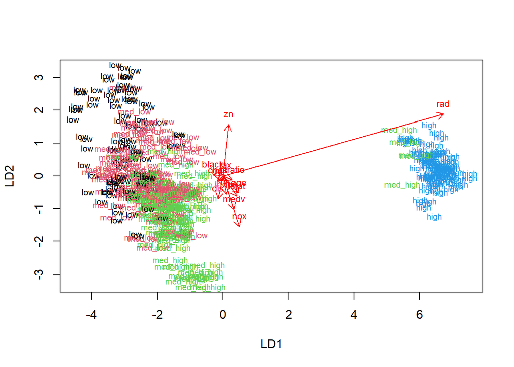

```r
#
# Here is the function for lda biplot arrows copied from Datacamp
lda.arrows <- function(x, myscale = 1, arrow_heads = 0.1, color = "red", tex = 0.75, choices = c(1,2)){
  heads <- coef(x)
  arrows(x0 = 0, y0 = 0,
         x1 = myscale * heads[,choices[1]],
         y1 = myscale * heads[,choices[2]], col=color, length = arrow_heads)
  text(myscale * heads[,choices], labels = row.names(heads),
       cex = tex, col=color, pos=3)
}


# target classes as numeric
classes <- as.numeric(train$crime)

# plot the lda results
plot(lda.fit, dimen = 2, col = classes, pch = classes)
lda.arrows(lda.fit, myscale = 2)
```

In this graph, it shows that “rad” variable is the most influential among other variables, hence the long arrow is pointing to it. Variable rad is a cluster of high (blue color) and med_high (green color)

### Task 6

```r
# save the correct classes from test data
correct_classes <- test$crime

# predicting classes with test data
lda.pred <- predict(lda.fit, newdata = test)

# cross tabulating the results
table(correct = correct_classes, predicted = lda.pred$class)
```

```
##           predicted
## correct    low med_low med_high high
##   low       10      15        1    0
##   med_low    3      16        4    0
##   med_high   1       5       16    1
##   high       0       0        1   29
```

### Task 7.

I am going to load the Boston dataset again by using the following lines of codes

```r
# Calling the library MASS
library(MASS)

#loading the data
data("Boston")

#scaling BIstin data set

boston_scaled_2 <- scale(Boston)
is.data.frame(boston_scaled_2)  #checking whether the boston_scalled2 is a data frame
```

```
## [1] FALSE
```

```r
boston_scaled_2 <- as.data.frame(boston_scaled_2)   # converting the boston_scalled_2 to data frame
is.data.frame(boston_scaled_2)
```

```
## [1] TRUE
```

Here we shall now Calculate the euclidean distances between the observations. The distance matrix is usually square matrix containing the pairwise distances of the observations.

```r
# calculating the euclidean distance matrix
dist_eu <- dist(boston_scaled_2)

# We nlw look at the summary of the distances
summary(dist_eu)
```

```
##    Min. 1st Qu.  Median    Mean 3rd Qu.    Max.
##  0.1343  3.4625  4.8241  4.9111  6.1863 14.3970
```

Here we will run k-means algorithm on the boston_scaled_2 data set with this codes below

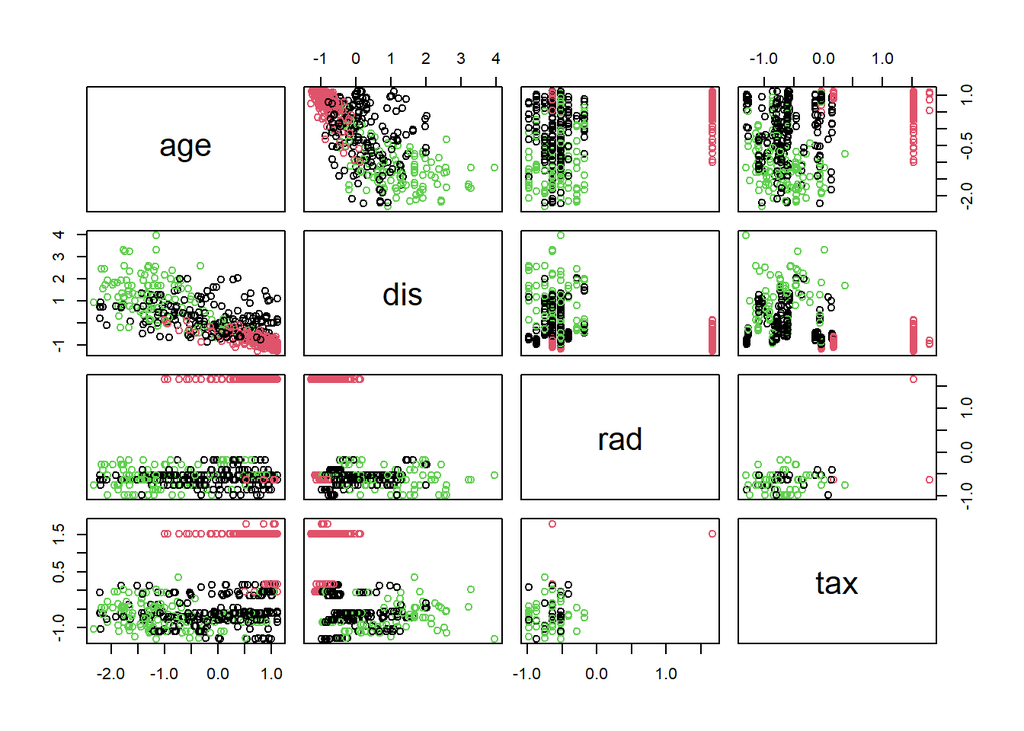

```r
# k-means clustering
km <-kmeans(boston_scaled_2, centers = 3)

#pairs(boston_scaled_2)

# plot the Boston dataset with clusters
pairs(boston_scaled_2[7:10], col = km$cluster)
```

After setting the kmeans cluster to 1,2,3,4,5 and 6, I think the optimal number of cluster is 3. From the diagram above, the k-mean cluster is 3 and the numbers of pairs() plot is reduced to 4 so that the visualization can be seen clearly.

It can be seen that there are 3 clusters in the plot separated with colors green, red, and black. The green cluster dominates, followed by the black cluster, and finally the red cluster.

*PLEASE NOTE THAT I OBSERVED THAT EVERYTIME YOU KNIT, THE CLUSTERING CHANGES SLIGHTLY IN TERMS OF COLORS AND CONCENTRATION7GROUPING*